# Exploratory Data Analysis Group 4

Ahsan Ahmad, Charlie Vandel, Rylan Tribush and Scott Silverstein

2024-10-06

# Introduction

### The Business Problem

Swire Coca-Cola faces a significant production shortfall across its six facilities, producing only 94.4% of its intended 192 million cases annually due to unplanned machinery breakdowns. These unexpected failures result in approximately $60 million in lost productivity each year. The current reactive maintenance process, reliant on an Internal Warehouse Controller (IWC) system that issues work orders only after breakdowns occur, creates delays in repairs and extends downtime.

### The Analytics Problem

To address the business problem, Swire Coca-Cola needs to analyze downtime records from its Internal Warehouse Controller (IWC) system. The objective is to identify patterns and causes of unplanned downtimes and develop a predictive maintenance model. The company has been collecting data for a while, but up until now has not been using the data effectively. By leveraging internal data generated from the IWC system, the predictive model will minimize downtime, improve output efficiency, and ultimately increase profits for the company.

### Our Goals for this Notebook

The goal of this notebook is to thoroughly explore machine downtime dataset that Swire Coca-Cola has created. This exploration will help us answer the following questions:

1. What are the distributions of the important variables in the dataset?
2. What are the basic summary statistics (mean, median, standard deviation, etc.) for each important predictor?
3. How to select a few most important and relevant predictors from the dataset?
4. Are there any missing values in the dataset? What method is used to clean the Data and remove them?
5. What are the relationships between different variables in the dataset? Are there any strong correlations that suggests potential predictive relationships?
6. How can the data be visualized to better understand its characteristics? e.g. creating different plots using ggplot like histograms, scatter plots, box plots, heatmaps etc.

# Description of the data

Initially a data set of 1,427,264 observations has been given by Swire which contains one identifier column (Order_ID) and 24 predictor variables. In this section we will produce summary statistics of the whole data and try to create insights from it.

```r
# Load Data and packages
library(tidyverse) #load libraries for project
library(dplyr)
library(ggplot2)
library(tidyr)
library(rpart)
library(rpart.plot)
library(skimr)
library(janitor)
library(corrplot)
library(lubridate)
library(survival)
library(survminer)
library(readr)
library(VIM)

data <- read.csv("IWC_Work_Orders_Extract.csv")

# Checking the data to look for Length, Min, Max, Mean, Outliers etc

str(data)
```

```
## 'data.frame':    1427264 obs. of  25 variables:
##  $ ORDER_ID                       : num  7.06e+08 7.04e+08 7.04e+08 7.04e+08 7.05e+08 ...
##  $ PLANT_ID                       : chr  "G812" "G812" "G812" "G812" ...
##  $ PRODUCTION_LOCATION            : chr  "ROMA" "ROMA" "ROMA" "ROMA" ...
##  $ EXECUTION_START_DATE           : chr  "2024-05-04" "2022-09-13" "2022-12-21" "2022-07-04" ...
##  $ EXECUTION_FINISH_DATE          : chr  "2024-05-12" "2022-09-13" "2022-12-21" "2022-07-04" ...
##  $ ACTUAL_START_TIME              : chr  "06:00:00.000" "06:00:00.000" "07:00:00.000" "06:00:00.000" ...
##  $ ACTUAL_FINISH_TIME             : chr  "23:04:08.000" "17:17:24.000" "07:00:00.000" "06:00:00.000" ...
##  $ ACTUAL_WORK_IN_MINUTES         : num  390 420 30 60 120 18 480 30 30 30 ...
##  $ MAINTENANCE_PLAN               : chr  "" "" "" "" ...
##  $ MAINTENANCE_ITEM               : int  NA NA NA NA NA 40534 NA NA NA NA ...
##  $ MAINTENANCE_ACTIVITY_TYPE      : chr  "Unplanned" "Unplanned" "Unplanned" "Unplanned" ...
##  $ ORDER_DESCRIPTION              : chr  "L2 GEARBOX LEAK (SEE ATTACHED)" "LINE 3 CONVEYOR AT CAN CODER" "BROKEN CONVEYOR RAIL" "LINE 3 CONVEYOR" ...
##  $ MAINTENANCE_TYPE_DESCRIPTION   : chr  "Corrective Maintenance Order" "Corrective Maintenance Order" "Corrective Maintenance Order" "Corrective Maintenance Order" ...
##  $ FUNCTIONAL_LOC                 : chr  "G812-PRD-L15-L03-L030-020" "G812-PRD-L15-L03-L030-020" "G812-PRD-L15-L03-L030-020" "G812-PRD-L15-L03-L030-020" ...
##  $ FUNCTIONAL_AREA_NODE_1_MODIFIED: chr  "PRODUCTION" "PRODUCTION" "PRODUCTION" "PRODUCTION" ...
##  $ FUNCTIONAL_AREA_NODE_2_MODIFIED: chr  "G812 PRD FILLER_ROTARY_CAN" "G812 PRD FILLER_ROTARY_CAN" "G812 PRD FILLER_ROTARY_CAN" "G812 PRD FILLER_ROTARY_CAN" ...
##  $ FUNCTIONAL_AREA_NODE_3_MODIFIED: chr  "G812 PRD FILLER_ROTARY_CAN LINE 3" "G812 PRD FILLER_ROTARY_CAN LINE 3" "G812 PRD FILLER_ROTARY_CAN LINE 3" "G812 PRD FILLER_ROTARY_CAN LINE 3" ...
##  $ FUNCTIONAL_AREA_NODE_4_MODIFIED: chr  "CONVEYOR" "CONVEYOR" "CONVEYOR" "CONVEYOR" ...
##  $ FUNCTIONAL_AREA_NODE_5_MODIFIED: chr  "FULL CAN CONVEYOR" "FULL CAN CONVEYOR" "FULL CAN CONVEYOR" "FULL CAN CONVEYOR" ...
##  $ EQUIPMENT_ID                   : int  300126812 300126812 300126812 300126812 300001088 300001088 300001088 300001033 300001033 300001033 ...
##  $ EQUIPMENT_DESC                 : chr  "FULL CAN CONVEYOR (FC41B)" "FULL CAN CONVEYOR (FC41B)" "FULL CAN CONVEYOR (FC41B)" "FULL CAN CONVEYOR (FC41B)" ...
##  $ EQUIP_CAT_DESC                 : chr  "Machines" "Machines" "Machines" "Machines" ...
##  $ EQUIP_START_UP_DATE            : chr  "2020-04-22" "2020-04-22" "2020-04-22" "2020-04-22" ...
##  $ EQUIP_VALID_FROM               : chr  "2020-02-10" "2020-02-10" "2020-02-10" "2020-02-10" ...
##  $ EQUIP_VALID_TO                 : chr  "9999-12-31" "9999-12-31" "9999-12-31" "9999-12-31" ...
```

```r
summary(data)
```

```
##     ORDER_ID           PLANT_ID         PRODUCTION_LOCATION
##  Min.   :1.000e+08   Length:1427264     Length:1427264
##  1st Qu.:4.023e+08   Class :character   Class :character
##  Median :7.044e+08   Mode  :character   Mode  :character
##  Mean   :4.561e+10
##  3rd Qu.:1.002e+09
##  Max.   :9.000e+11
##
##  EXECUTION_START_DATE EXECUTION_FINISH_DATE ACTUAL_START_TIME
##  Length:1427264       Length:1427264        Length:1427264
##  Class :character     Class :character      Class :character
##  Mode  :character     Mode  :character      Mode  :character
##
##
##
##
##  ACTUAL_FINISH_TIME ACTUAL_WORK_IN_MINUTES MAINTENANCE_PLAN   MAINTENANCE_ITEM
##  Length:1427264     Min.   :     0.0       Length:1427264     Min.   : 39801
##  Class :character   1st Qu.:    12.0       Class :character   1st Qu.: 41046
##  Mode  :character   Median :    48.0       Mode  :character   Median :112995
##                     Mean   :    88.6                          Mean   :115847
##                     3rd Qu.:    90.0                          3rd Qu.:134702
##                     Max.   :330184.8                          Max.   :346352
##                                                               NA's   :1274670
##  MAINTENANCE_ACTIVITY_TYPE ORDER_DESCRIPTION  MAINTENANCE_TYPE_DESCRIPTION
##  Length:1427264            Length:1427264     Length:1427264
##  Class :character          Class :character   Class :character
##  Mode  :character          Mode  :character   Mode  :character
##
##
##
##
##  FUNCTIONAL_LOC     FUNCTIONAL_AREA_NODE_1_MODIFIED
##  Length:1427264     Length:1427264
##  Class :character   Class :character
##  Mode  :character   Mode  :character
##
##
##
##
```

[output cut: 17 more lines]

```
##  Min.   :200087110   Length:1427264     Length:1427264     Length:1427264
##  1st Qu.:300009161   Class :character   Class :character   Class :character
##  Median :300017751   Mode  :character   Mode  :character   Mode  :character
##  Mean   :300260910
##  3rd Qu.:300026939
##  Max.   :400029000
##  NA's   :1135469
##  EQUIP_VALID_FROM   EQUIP_VALID_TO
##  Length:1427264     Length:1427264
##  Class :character   Class :character
##  Mode  :character   Mode  :character
##
##
##
##
```

```r
# Displaying the first few rows of data
head(data)
```

```
##    ORDER_ID PLANT_ID PRODUCTION_LOCATION EXECUTION_START_DATE
## 1 705642457     G812                ROMA           2024-05-04
## 2 704191697     G812                ROMA           2022-09-13
## 3 704466547     G812                ROMA           2022-12-21
## 4 703834477     G812                ROMA           2022-07-04
## 5 704661125     G291               MONZA           2023-03-15
## 6 704948720     G291               MONZA           2023-09-08
##   EXECUTION_FINISH_DATE ACTUAL_START_TIME ACTUAL_FINISH_TIME
## 1            2024-05-12      06:00:00.000       23:04:08.000
## 2            2022-09-13      06:00:00.000       17:17:24.000
## 3            2022-12-21      07:00:00.000       07:00:00.000
## 4            2022-07-04      06:00:00.000       06:00:00.000
## 5            2023-03-15      07:00:00.000       07:00:00.000
## 6            2023-09-08      07:00:00.000       07:00:00.000
##   ACTUAL_WORK_IN_MINUTES MAINTENANCE_PLAN MAINTENANCE_ITEM
```

[output cut: 48 more lines]

# Data Cleaning and Preprocessing

## Handling Missing Data

```r
# Display the number of NA values per column

missing_values <- colSums(is.na(data))
print(missing_values)
```

```
##                        ORDER_ID                        PLANT_ID
##                               0                               0
##             PRODUCTION_LOCATION            EXECUTION_START_DATE
##                               0                               0
##           EXECUTION_FINISH_DATE               ACTUAL_START_TIME
##                               0                               0
##              ACTUAL_FINISH_TIME          ACTUAL_WORK_IN_MINUTES
##                               0                               0
##                MAINTENANCE_PLAN                MAINTENANCE_ITEM
##                               0                         1274670
##       MAINTENANCE_ACTIVITY_TYPE               ORDER_DESCRIPTION
##                               0                               0
##    MAINTENANCE_TYPE_DESCRIPTION                  FUNCTIONAL_LOC
##                               0                               0
## FUNCTIONAL_AREA_NODE_1_MODIFIED FUNCTIONAL_AREA_NODE_2_MODIFIED
##                               0                               0
## FUNCTIONAL_AREA_NODE_3_MODIFIED FUNCTIONAL_AREA_NODE_4_MODIFIED
##                               0                               0
## FUNCTIONAL_AREA_NODE_5_MODIFIED                    EQUIPMENT_ID
##                               0                         1135469
##                  EQUIPMENT_DESC                  EQUIP_CAT_DESC
##                               0                               0
##             EQUIP_START_UP_DATE                EQUIP_VALID_FROM
##                               0                               0
##                  EQUIP_VALID_TO
##                               0
```

```r
# Imputing Missing Equipment IDs and Maintenance Items with the preceding values using fill()

data <- data %>%
  arrange(EQUIPMENT_ID, EXECUTION_START_DATE) %>%  #Ensuring the data is ordered correctly by equipment and date
  fill(EQUIPMENT_ID, MAINTENANCE_ITEM, .direction = "down")

# Chceking for missing values again

na_values <- colSums(is.na(data))
print(na_values)
```

```
##                        ORDER_ID                        PLANT_ID
##                               0                               0
##             PRODUCTION_LOCATION            EXECUTION_START_DATE
##                               0                               0
##           EXECUTION_FINISH_DATE               ACTUAL_START_TIME
##                               0                               0
##              ACTUAL_FINISH_TIME          ACTUAL_WORK_IN_MINUTES
##                               0                               0
##                MAINTENANCE_PLAN                MAINTENANCE_ITEM
##                               0                             125
##       MAINTENANCE_ACTIVITY_TYPE               ORDER_DESCRIPTION
##                               0                               0
##    MAINTENANCE_TYPE_DESCRIPTION                  FUNCTIONAL_LOC
##                               0                               0
## FUNCTIONAL_AREA_NODE_1_MODIFIED FUNCTIONAL_AREA_NODE_2_MODIFIED
##                               0                               0
## FUNCTIONAL_AREA_NODE_3_MODIFIED FUNCTIONAL_AREA_NODE_4_MODIFIED
##                               0                               0
## FUNCTIONAL_AREA_NODE_5_MODIFIED                    EQUIPMENT_ID
##                               0                               0
##                  EQUIPMENT_DESC                  EQUIP_CAT_DESC
##                               0                               0
##             EQUIP_START_UP_DATE                EQUIP_VALID_FROM
##                               0                               0
##                  EQUIP_VALID_TO
##                               0
```

The numbers above show that about 90% of the column “MAINTENANCE_ITEM” contains NA values and about 80% of the column “EQUIPMENT_ID” contains NA values. The high percentage of NA values is likely caused by the roughly 60 smaller components for each of the equipment. Therefore, we can’t remove these rows nor can we impute any ID numbers for these values. For the sake of this EDA and to prepare data for survival analysis let’s assume that the Equipment ID is the same as the preceding one before NA values since it may be possible that one Equipment ID is associated with approximately 60 smaller components.

## Changing Column Data Types

```r
# Converting Date and Time Columns to type "Date" and Minutes accordingly

data <- data %>%
  mutate(
    EXECUTION_START_DATE = as.Date(EXECUTION_START_DATE, format = "%Y-%m-%d"),
    EXECUTION_FINISH_DATE = as.Date(EXECUTION_FINISH_DATE, format = "%Y-%m-%d"),
    EQUIP_START_UP_DATE = as.Date(EQUIP_START_UP_DATE, format = "%Y-%m-%d"),
    EQUIP_VALID_FROM = as.Date(EQUIP_VALID_FROM, format = "%Y-%m-%d"),
    EQUIP_VALID_TO = as.Date(EQUIP_VALID_TO, format = "%Y-%m-%d"),
    ACTUAL_START_TIME = hms(ACTUAL_START_TIME),
    ACTUAL_FINISH_TIME = hms(ACTUAL_FINISH_TIME)
  )

# Converting Non-Numeric and non-date type variables to factor
data <- data %>%
  mutate(
    PLANT_ID = factor(PLANT_ID),
    PRODUCTION_LOCATION = factor(PRODUCTION_LOCATION),
    MAINTENANCE_ACTIVITY_TYPE = factor(MAINTENANCE_ACTIVITY_TYPE),
    MAINTENANCE_TYPE_DESCRIPTION = factor(MAINTENANCE_TYPE_DESCRIPTION),
    FUNCTIONAL_AREA_NODE_1_MODIFIED = factor(FUNCTIONAL_AREA_NODE_1_MODIFIED),
    FUNCTIONAL_AREA_NODE_2_MODIFIED = factor(FUNCTIONAL_AREA_NODE_2_MODIFIED),
    FUNCTIONAL_AREA_NODE_3_MODIFIED = factor(FUNCTIONAL_AREA_NODE_3_MODIFIED),
    FUNCTIONAL_AREA_NODE_4_MODIFIED = factor(FUNCTIONAL_AREA_NODE_4_MODIFIED),
    FUNCTIONAL_AREA_NODE_5_MODIFIED = factor(FUNCTIONAL_AREA_NODE_5_MODIFIED),
    EQUIP_CAT_DESC = factor(EQUIP_CAT_DESC),
    MAINTENANCE_PLAN = factor(MAINTENANCE_PLAN),
    EQUIPMENT_ID = factor(EQUIPMENT_ID),
    MAINTENANCE_ITEM = factor(MAINTENANCE_ITEM)
  )

# Looking for the summary again for the new data

summary(data)
```

```
##     ORDER_ID         PLANT_ID       PRODUCTION_LOCATION EXECUTION_START_DATE
##  Min.   :1.000e+08   G221:290975   COTA       :116303   Min.   :2013-08-19
##  1st Qu.:4.023e+08   G261:630903   MONACO     : 84694   1st Qu.:2019-02-09
##  Median :7.044e+08   G291:225279   MONZA      :225279   Median :2020-12-09
##  Mean   :4.561e+10   G811: 84694   ROMA       : 79110   Mean   :2020-12-20
##  3rd Qu.:1.002e+09   G812: 79110   SILVERSTONE:630903   3rd Qu.:2022-12-07
##  Max.   :9.000e+11   G816:116303   SUZUKA     :290975   Max.   :2024-08-30
##
##  EXECUTION_FINISH_DATE ACTUAL_START_TIME
##  Min.   :2016-07-25    Min.   :0S
##  1st Qu.:2019-02-11    1st Qu.:6H 0M 0S
##  Median :2020-12-10    Median :11H 39M 41S
##  Mean   :2020-12-21    Mean   :11H 7M 21.3360983452149S
##  3rd Qu.:2022-12-08    3rd Qu.:18H 17M 0S
##  Max.   :2024-08-30    Max.   :23H 59M 51S
##
##  ACTUAL_FINISH_TIME                  ACTUAL_WORK_IN_MINUTES
##  Min.   :0S                          Min.   :     0.0
##  1st Qu.:6H 0M 0S                    1st Qu.:    12.0
##  Median :15H 40M 0S                  Median :    48.0
##  Mean   :12H 47M 39.6797487273216S   Mean   :    88.6
##  3rd Qu.:20H 30M 0S                  3rd Qu.:    90.0
##  Max.   :23H 59M 59S                 Max.   :330184.8
##
##      MAINTENANCE_PLAN   MAINTENANCE_ITEM  MAINTENANCE_ACTIVITY_TYPE
##              :1274670   40113  :1135680   Planned  : 150387
##  000000022943:   1327   287851 :   1761   Unplanned:1276877
##  G26111606   :   1311   134750 :   1755
##  G812200051  :   1067   90599  :   1634
##  G812200064  :   1067   229363 :   1537
##  G811100990  :   1065   (Other): 284772
##  (Other)     : 146757   NA's   :    125
##  ORDER_DESCRIPTION                MAINTENANCE_TYPE_DESCRIPTION
##  Length:1427264                                 :1135469
##  Class :character   Administrative Order        :   6161
##  Mode  :character   Breakdown Maintenance Order :      5
##                     Capital Order               :     22
##                     Corrective Maintenance Order: 134074
##                     Preventive Maintenance Order: 151533
##
```

[output cut: 33 more lines]

```
##  Length:1427264                               :1347817   Min.   :1960-01-01
##  Class :character   Machines                  :  79224   1st Qu.:2017-02-15
##  Mode  :character   Plant & Buildings         :     77   Median :2017-02-15
##                     Production resources/tools:     82   Mean   :2017-06-19
##                     Test/measurement equipment:     64   3rd Qu.:2018-05-07
##                                                          Max.   :2024-05-16
##                                                          NA's   :1347817
##  EQUIP_VALID_FROM     EQUIP_VALID_TO
##  Min.   :2017-02-15   Min.   :9999-12-31
##  1st Qu.:2017-02-15   1st Qu.:9999-12-31
##  Median :2017-03-15   Median :9999-12-31
##  Mean   :2019-03-03   Mean   :9999-12-31
##  3rd Qu.:2020-08-11   3rd Qu.:9999-12-31
##  Max.   :2024-05-20   Max.   :9999-12-31
##  NA's   :1347817      NA's   :1347817
```

## Creating variables to prepare data for survival analysis

```r
# Failure - A binary variable that is 1 if there was a machine failure and 0 otherwise

data <- data %>%
  mutate(
    failure = ifelse(MAINTENANCE_ACTIVITY_TYPE == "Unplanned", 1, 0)
  )

# Sorting data by Equipment ID and execution start date to extract the time taken for failure to occur
data <- data %>%
  arrange(EQUIPMENT_ID, EXECUTION_START_DATE)

# Calculating the time since failure and time since installation for each Equipment
data <- data %>%
  group_by(EQUIPMENT_ID) %>%
  mutate(
    time_since_failure = as.numeric(difftime(EXECUTION_START_DATE, lag(EXECUTION_START_DATE), units = "days")),
    time_since_installation = as.numeric(difftime(EXECUTION_START_DATE, EQUIP_VALID_FROM, units = "days"))
  ) %>%
  ungroup()

# Looking at the new variables by getting the summary of the data again
summary(data)
```

```
##     ORDER_ID         PLANT_ID       PRODUCTION_LOCATION EXECUTION_START_DATE
##  Min.   :1.000e+08   G221:290975   COTA       :116303   Min.   :2013-08-19
##  1st Qu.:4.023e+08   G261:630903   MONACO     : 84694   1st Qu.:2019-02-09
##  Median :7.044e+08   G291:225279   MONZA      :225279   Median :2020-12-09
##  Mean   :4.561e+10   G811: 84694   ROMA       : 79110   Mean   :2020-12-20
##  3rd Qu.:1.002e+09   G812: 79110   SILVERSTONE:630903   3rd Qu.:2022-12-07
##  Max.   :9.000e+11   G816:116303   SUZUKA     :290975   Max.   :2024-08-30
##
##  EXECUTION_FINISH_DATE ACTUAL_START_TIME
##  Min.   :2016-07-25    Min.   :0S
##  1st Qu.:2019-02-11    1st Qu.:6H 0M 0S
##  Median :2020-12-10    Median :11H 39M 41S
##  Mean   :2020-12-21    Mean   :11H 7M 21.3360983452221S
##  3rd Qu.:2022-12-08    3rd Qu.:18H 17M 0S
##  Max.   :2024-08-30    Max.   :23H 59M 51S
##
##  ACTUAL_FINISH_TIME                  ACTUAL_WORK_IN_MINUTES
##  Min.   :0S                          Min.   :     0.0
##  1st Qu.:6H 0M 0S                    1st Qu.:    12.0
##  Median :15H 40M 0S                  Median :    48.0
##  Mean   :12H 47M 39.6797487273216S   Mean   :    88.6
##  3rd Qu.:20H 30M 0S                  3rd Qu.:    90.0
##  Max.   :23H 59M 59S                 Max.   :330184.8
##
##      MAINTENANCE_PLAN   MAINTENANCE_ITEM  MAINTENANCE_ACTIVITY_TYPE
##              :1274670   40113  :1135680   Planned  : 150387
##  000000022943:   1327   287851 :   1761   Unplanned:1276877
##  G26111606   :   1311   134750 :   1755
##  G812200051  :   1067   90599  :   1634
##  G812200064  :   1067   229363 :   1537
##  G811100990  :   1065   (Other): 284772
##  (Other)     : 146757   NA's   :    125
##  ORDER_DESCRIPTION                MAINTENANCE_TYPE_DESCRIPTION
##  Length:1427264                                 :1135469
##  Class :character   Administrative Order        :   6161
##  Mode  :character   Breakdown Maintenance Order :      5
##                     Capital Order               :     22
##                     Corrective Maintenance Order: 134074
##                     Preventive Maintenance Order: 151533
##
```

[output cut: 41 more lines]

```
##  Min.   :2017-02-15   Min.   :9999-12-31   Min.   :0.0000   Min.   :   0.000
##  1st Qu.:2017-02-15   1st Qu.:9999-12-31   1st Qu.:1.0000   1st Qu.:   0.000
##  Median :2017-03-15   Median :9999-12-31   Median :1.0000   Median :   0.000
##  Mean   :2019-03-03   Mean   :9999-12-31   Mean   :0.8946   Mean   :   2.906
##  3rd Qu.:2020-08-11   3rd Qu.:9999-12-31   3rd Qu.:1.0000   3rd Qu.:   0.000
##  Max.   :2024-05-20   Max.   :9999-12-31   Max.   :1.0000   Max.   :2479.000
##  NA's   :1347817      NA's   :1347817                       NA's   :2956
##  time_since_installation
##  Min.   :-2480.0
##  1st Qu.:  246.0
##  Median :  885.0
##  Mean   :  829.7
##  3rd Qu.: 1615.0
##  Max.   : 2752.0
##  NA's   :1347817
```

The summary above tells us that almost 90% of maintenance is unplanned and occurs due to failure in a piece of equipment or it’s part. The time since failure has a low mean of around 3 days since a lot of the Equipment ID’s were imputed with 400029000 and hence the failure time for them are calculated as zero.

# Exploratory Data Visualizations

For the sake of showing data patterns through visualizations we shall take out the 400029000 that we imputed. We will start with some univariate analysis of important variables and than will move to bivariate and multivariate analysis.

```r
# Removing Equipment ID 400029000 and Outliers from the data set

data_clean <- data %>%
  filter(EQUIPMENT_ID != 400029000) %>%
  filter(ACTUAL_WORK_IN_MINUTES < 20000) %>%
  mutate(failure = factor(failure)) %>%
  filter(time_since_installation > 0)

# Checking the summary characteristics of the clean data
summary(data_clean)
```

```
##     ORDER_ID         PLANT_ID      PRODUCTION_LOCATION EXECUTION_START_DATE
##  Min.   :700005262   G221:  376   COTA       :12906    Min.   :2017-02-27
##  1st Qu.:701779566   G261: 1763   MONACO     : 3199    1st Qu.:2019-11-16
##  Median :703224452   G291:43645   MONZA      :43645    Median :2021-11-23
##  Mean   :703262688   G811: 3199   ROMA       : 5147    Mean   :2021-08-25
##  3rd Qu.:704894927   G812: 5147   SILVERSTONE: 1763    3rd Qu.:2023-07-08
##  Max.   :705914514   G816:12906   SUZUKA     :  376    Max.   :2024-08-29
##
##  EXECUTION_FINISH_DATE ACTUAL_START_TIME
##  Min.   :2017-02-27    Min.   :0S
##  1st Qu.:2019-11-17    1st Qu.:6H 0M 0S
##  Median :2021-11-23    Median :7H 0M 0S
##  Mean   :2021-08-25    Mean   :7H 12M 25.1523062235538S
##  3rd Qu.:2023-07-08    3rd Qu.:7H 0M 0S
##  Max.   :2024-08-30    Max.   :23H 59M 17S
##
##  ACTUAL_FINISH_TIME                ACTUAL_WORK_IN_MINUTES     MAINTENANCE_PLAN
##  Min.   :2M 45S                    Min.   :   0.00                    :21020
##  1st Qu.:7H 0M 0S                  1st Qu.:  18.00        000000022943:  890
##  Median :7H 0M 0S                  Median :  31.20        000000040761:  795
##  Mean   :8H 0M 8.96791276323711S   Mean   :  76.59        G29110843   :  714
##  3rd Qu.:8H 0M 0S                  3rd Qu.:  72.00        G816SC1447  :  694
##  Max.   :23H 59M 59S               Max.   :9055.20        G816SC1444  :  572
##                                                           (Other)     :42351
##  MAINTENANCE_ITEM MAINTENANCE_ACTIVITY_TYPE ORDER_DESCRIPTION
##  229363 : 1537    Planned  :44137           Length:67036
##  229214 :  905    Unplanned:22899           Class :character
##  207536 :  766                              Mode  :character
##  207535 :  552
##  226576 :  511
##  (Other):62763
##  NA's   :    2
##                MAINTENANCE_TYPE_DESCRIPTION FUNCTIONAL_LOC
##                              :    0         Length:67036
##  Administrative Order        : 1719         Class :character
##  Breakdown Maintenance Order :    2         Mode  :character
##  Capital Order               :    0
##  Corrective Maintenance Order:20456
##  Preventive Maintenance Order:44859
##
```

[output cut: 41 more lines]

```
##  Min.   :1960-01-01   Min.   :2017-02-15   Min.   :9999-12-31   0:44137
##  1st Qu.:2017-02-15   1st Qu.:2017-02-15   1st Qu.:9999-12-31   1:22899
##  Median :2017-02-15   Median :2017-02-25   Median :9999-12-31
##  Mean   :2017-08-06   Mean   :2018-05-15   Mean   :9999-12-31
##  3rd Qu.:2019-06-01   3rd Qu.:2019-10-06   3rd Qu.:9999-12-31
##  Max.   :2024-05-16   Max.   :2024-05-20   Max.   :9999-12-31
##
##  time_since_failure time_since_installation
##  Min.   :   0.00    Min.   :   1
##  1st Qu.:   0.00    1st Qu.: 559
##  Median :   2.00    Median :1119
##  Mean   :  12.34    Mean   :1198
##  3rd Qu.:   9.00    3rd Qu.:1754
##  Max.   :2388.00    Max.   :2752
##  NA's   :592
```

## Understanding where and how often the failures occur

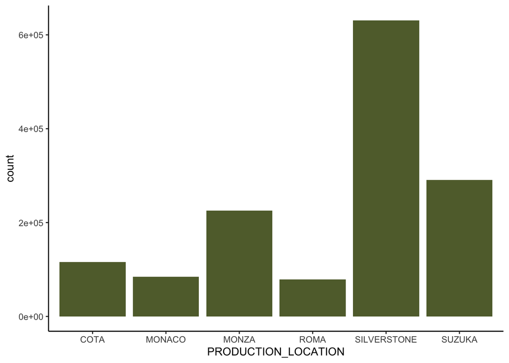

```r
# A count of the number of downtimes by location
ggplot(data, aes(PRODUCTION_LOCATION)) +
  geom_bar(fill = "#606c38") +
  theme_classic()
```

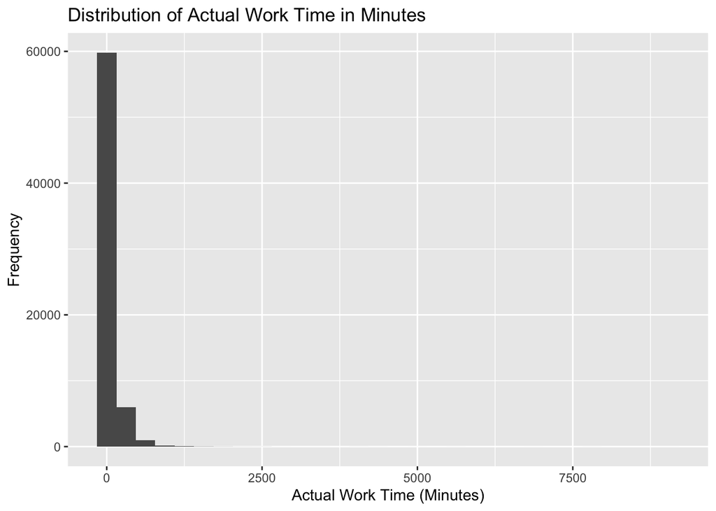

```r
# Histogram of Actual Work in Minutes

ggplot(data = data_clean,
       mapping = aes(x = ACTUAL_WORK_IN_MINUTES)) +
  geom_histogram() +
  labs(title = "Distribution of Actual Work Time in Minutes",
       x = "Actual Work Time (Minutes)", y = "Frequency")
```

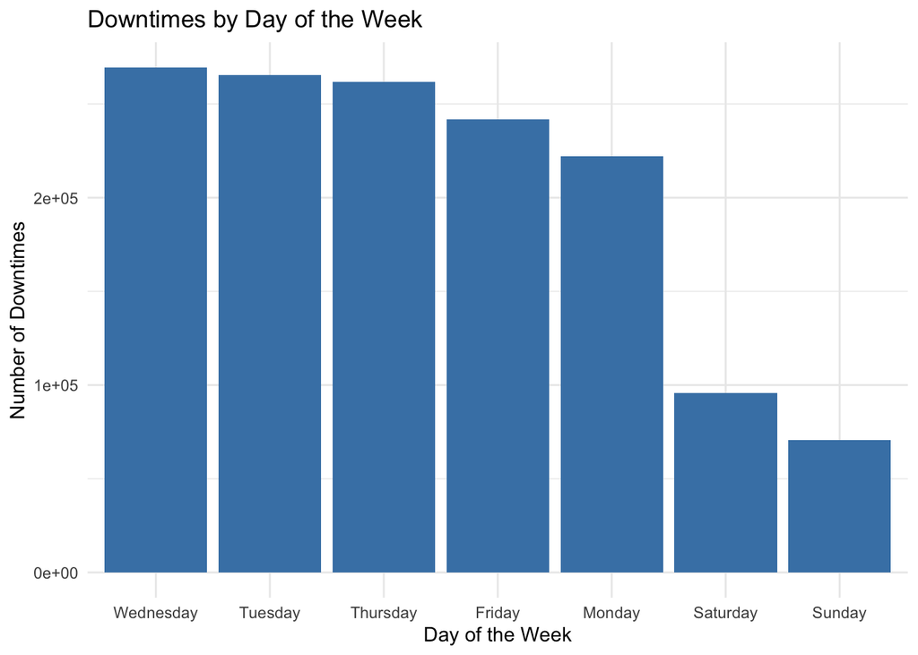

```r
# Group data by day of the week and count downtimes
data <- data %>%
  mutate(day_of_week = format(EXECUTION_START_DATE, "%A"),
         month = format(EXECUTION_START_DATE, "%B"))
downtime_by_day <- data %>%
  group_by(day_of_week) %>%
  summarise(count = n())

# Plot downtimes by day of the week
ggplot(downtime_by_day, aes(x = reorder(day_of_week, -count), y = count)) +
  geom_bar(stat = "identity", fill = "steelblue") +
  labs(title = "Downtimes by Day of the Week", x = "Day of the Week", y = "Number of Downtimes") +
  theme_minimal()
```

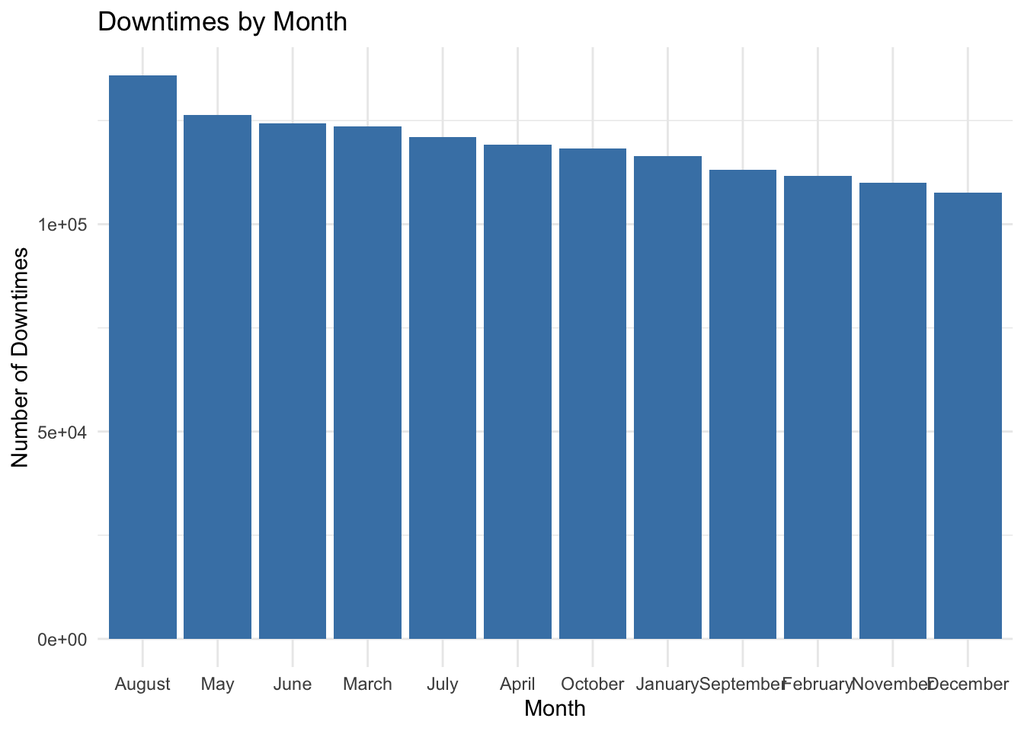

```r
# Group data by month and count downtimes
downtime_by_month <- data %>%
  group_by(month) %>%
  summarise(count = n())

# Plot downtimes by month
ggplot(downtime_by_month, aes(x = reorder(month, -count), y = count)) +
  geom_bar(stat = "identity", fill = "steelblue") +
  labs(title = "Downtimes by Month", x = "Month", y = "Number of Downtimes") +
  theme_minimal()
```

The first chart, showing downtimes by the day of the week, reveals that the highest number of downtimes occurs mid-week, particularly on Wednesday, Tuesday, and Thursday. As we move toward the weekend, the number of downtimes decreases, with the fewest incidents happening on Sunday, followed closely by Saturday. This suggests that the operational intensity is higher during weekdays, contributing to more frequent downtimes, while reduced activity on weekends correlates with fewer breakdowns.

In the second chart, which examines downtimes by month, we observe that August experiences the highest number of downtimes, followed closely by May and June. The remaining months exhibit relatively consistent downtime levels, though November and December have the lowest number of occurrences. This could indicate seasonal patterns in production or maintenance scheduling, where summer months experience more stress on the machinery, possibly due to higher production demands or environmental factors affecting the equipment. Together, both charts suggest that operational and seasonal factors heavily influence the frequency of downtimes, with peak activities during mid-week and summer months likely driving higher machine stress and breakdowns.

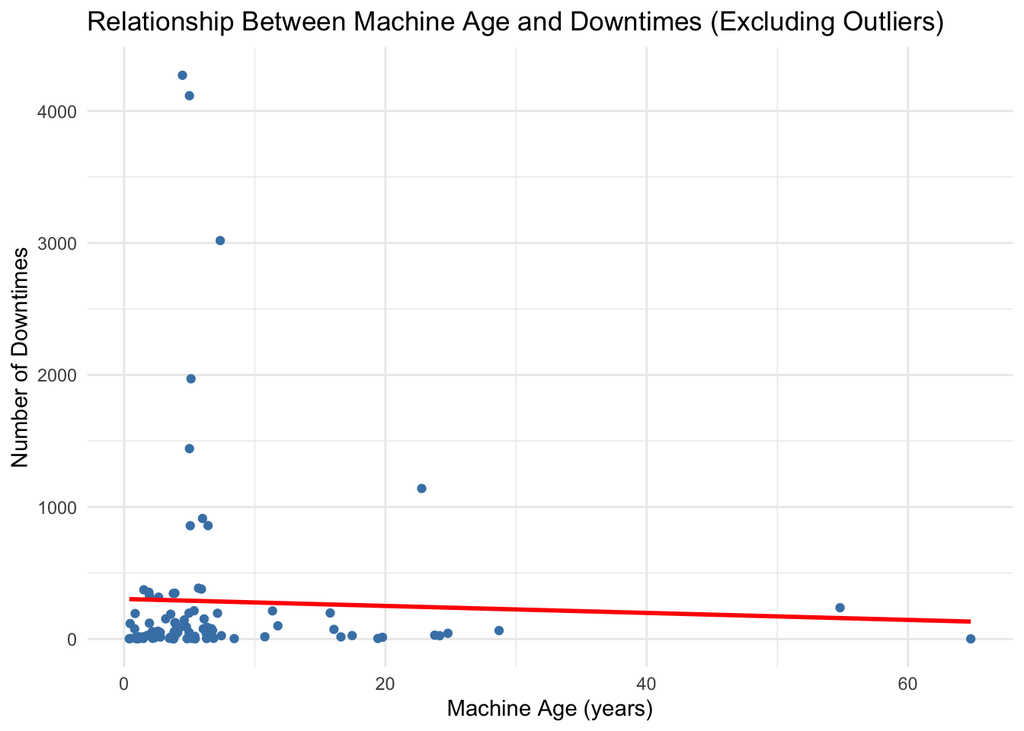

```r
# Filter out the outlier (assuming downtime counts over 10,000 are extreme)

data <- data %>%
  mutate(MACHINE_AGE = as.numeric(difftime(Sys.Date(), EQUIP_START_UP_DATE, units = "days")) / 365)

age_breakdowns <- data %>%
  group_by(MACHINE_AGE) %>%
  summarise(downtime_count = n()) %>%
  arrange(MACHINE_AGE)

data_filtered <- age_breakdowns %>%
  filter(downtime_count < 10000)  # Adjust this threshold based on your data

# Plot machine age against downtime count without the outlier
ggplot(data_filtered, aes(x = MACHINE_AGE, y = downtime_count)) +
  geom_point(color = "steelblue") +
  geom_smooth(method = "lm", se = FALSE, color = "red") +
  labs(title = "Relationship Between Machine Age and Downtimes (Excluding Outliers)",
       x = "Machine Age (years)",
       y = "Number of Downtimes") +
  theme_minimal()
```

This scatter plot shows the relationship between machine age and the number of downtimes, with outliers excluded. The data points indicate that the majority of machines, especially those under 20 years old, experience varying numbers of downtimes, with some machines having significantly more breakdowns. However, the trend line (in red) suggests a slight negative correlation between machine age and downtimes, indicating that older machines tend to have fewer recorded breakdowns. This could suggest that older machines are maintained more effectively or used less frequently, though further investigation is needed to fully understand this trend.

## An example of going deep in a narrow scope

The end goal will be predicting when to order individual parts for individual machines in an efficient manner. Thus, we were interested in how breaking down one equipment ID to its daily downtimes would help discover trends over time.

```r
# Start by finding which Equipment IDs cause the most downtime
top_20_IDs <- data %>%
  group_by(EQUIPMENT_ID) %>%
  summarise(total_downtime = sum(ACTUAL_WORK_IN_MINUTES, na.rm = TRUE)) %>%
  arrange(desc(total_downtime)) %>%
  top_n(20, total_downtime)

# View the result
top_20_IDs
```

```
## # A tibble: 20 × 2
##    EQUIPMENT_ID total_downtime
##    <fct>                 <dbl>
##  1 400029000        100328047.
##  2 300025792           484506
##  3 300017654           404194.
##  4 300009177           390295.
##  5 300017655           376677.
##  6 300115000           331877.
##  7 300019388           312628.
##  8 300009199           288932.
##  9 300017247           287204.
## 10 300026891           276620.
## 11 300017312           258617.
## 12 300019362           252405
## 13 300001505           238962.
## 14 300009114           229948.
## 15 300001509           219697.
## 16 300017248           216219.
## 17 300017313           209338.
## 18 300001510           198628.
## 19 300001113           176932.
## 20 300017746           169420.
```

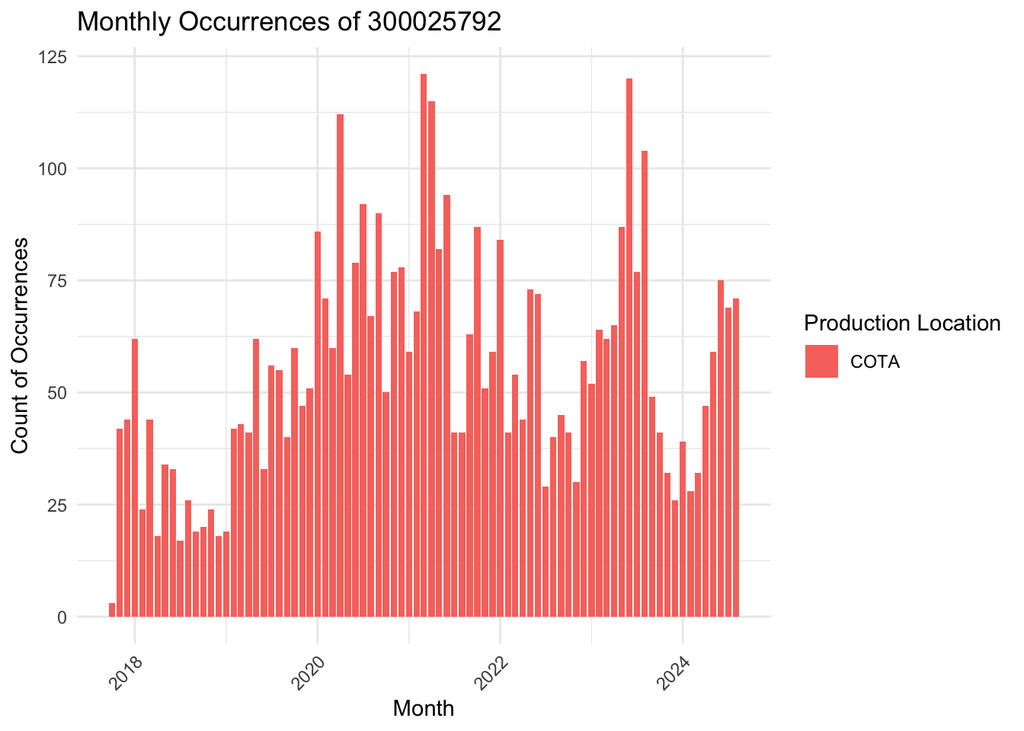

```r
# Then just look at the top EQUIPMENT_ID for downtime
filtered_df <- data %>%
  dplyr::filter(EQUIPMENT_ID == "300025792") %>%
  mutate(month = floor_date(as.Date(EXECUTION_START_DATE), "month"))

# Create the plot with binned dates (monthly)
ggplot(filtered_df, aes(x = month, fill = PRODUCTION_LOCATION)) +
  geom_bar() +
  labs(title = "Monthly Occurrences of 300025792",
       x = "Month",
       y = "Count of Occurrences",
       fill = "Production Location") +
  theme_minimal() +
  theme(axis.text.x = element_text(angle = 45, hjust = 1))
```

Unfortunately because this equipment ID is just used in one location, we are unable to compare if other locations have similar results. Lets dig deeper into this equipment ID, now by total downtime in minutes.

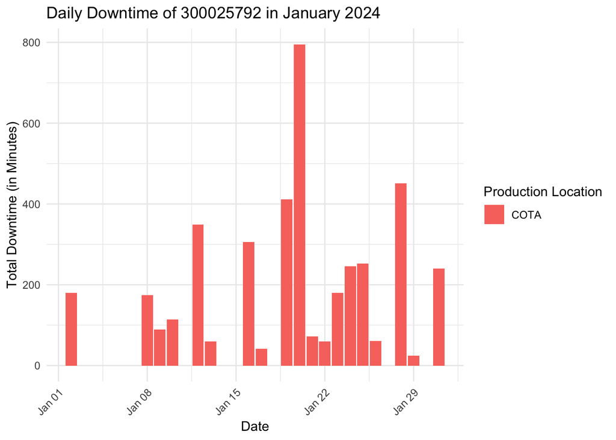

```r
# Filter for the specific equipment and month (January 2024)
filtered_df <- data %>%
  dplyr::filter(EQUIPMENT_ID == "300025792") %>%
  mutate(date = as.Date(EXECUTION_START_DATE)) %>%
  dplyr::filter(month(EXECUTION_START_DATE) == 1, year(EXECUTION_START_DATE) == 2024)

# Summarize the total downtime per day
downtime_per_day <- filtered_df %>%
  group_by(date, PRODUCTION_LOCATION) %>%
  summarise(total_downtime = sum(ACTUAL_WORK_IN_MINUTES, na.rm = TRUE))

# Create the plot showing total downtime per day in January 2024
ggplot(downtime_per_day, aes(x = date, y = total_downtime, fill = PRODUCTION_LOCATION)) +
  geom_col() +
  labs(title = "Daily Downtime of 300025792 in January 2024",
       x = "Date",
       y = "Total Downtime (in Minutes)",
       fill = "Production Location") +
  theme_minimal() +
  theme(axis.text.x = element_text(angle = 45, hjust = 1))
```

The inconsistency of this one part failing as well as the amount of time it takes to replace is telling. It would be interesting to know if this was caused by the part not being in stock, or the repair process itself.

Finally, because the top equipment IDs were related to the machinery location “Filler Rotary Can” lets compare this failure across locations:

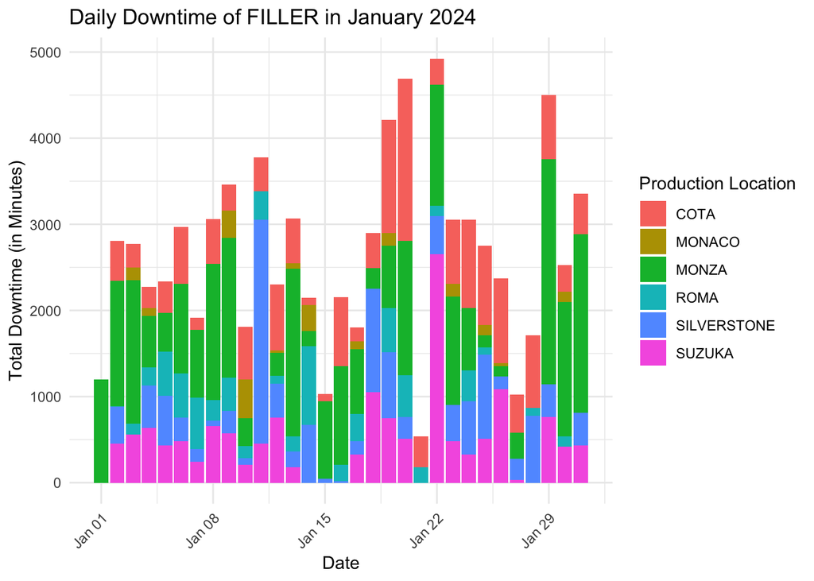

```r
# Filter for the specific equipment and month (January 2024)
filtered_df <- data %>%
  dplyr::filter(FUNCTIONAL_AREA_NODE_4_MODIFIED == "FILLER") %>%
  mutate(date = as.Date(EXECUTION_START_DATE)) %>%
  dplyr::filter(month(EXECUTION_START_DATE) == 1, year(EXECUTION_START_DATE) == 2024)

# Summarize the total downtime per day
downtime_per_day <- filtered_df %>%
  group_by(date, PRODUCTION_LOCATION) %>%
  summarise(total_downtime = sum(ACTUAL_WORK_IN_MINUTES, na.rm = TRUE))

# Create the plot showing total downtime per day in January 2024
ggplot(downtime_per_day, aes(x = date, y = total_downtime, fill = PRODUCTION_LOCATION)) +
  geom_col() +
  labs(title = "Daily Downtime of FILLER in January 2024",
       x = "Date",
       y = "Total Downtime (in Minutes)",
       fill = "Production Location") +
  theme_minimal() +
  theme(axis.text.x = element_text(angle = 45, hjust = 1))
```

Interestingly, there is not a consistent amount of downtime in each day working on this equipment. The jump from January 21 to 22 is indicative of potential missing data, or an underlying trend.

## Comparing Planned vs Unplanned failures

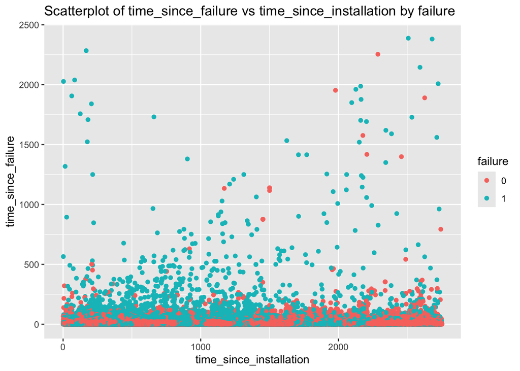

```r
# Scatter plot between two continuous variable with target as color
data_clean %>%
  ggplot(mapping = aes(x = time_since_installation, y = time_since_failure, color = failure)) +
  geom_point() +
  labs(title = "Scatterplot of time_since_failure vs time_since_installation by failure")
```

It can be seen from the scatter plot above that as the time since equipment is installed increases, the time between failures is more at the start and end of the graph. This suggests that the pieces of equipment are either performing without failure at the start when they are initially installed or at the end of their lifecycle due to planned maintenance.

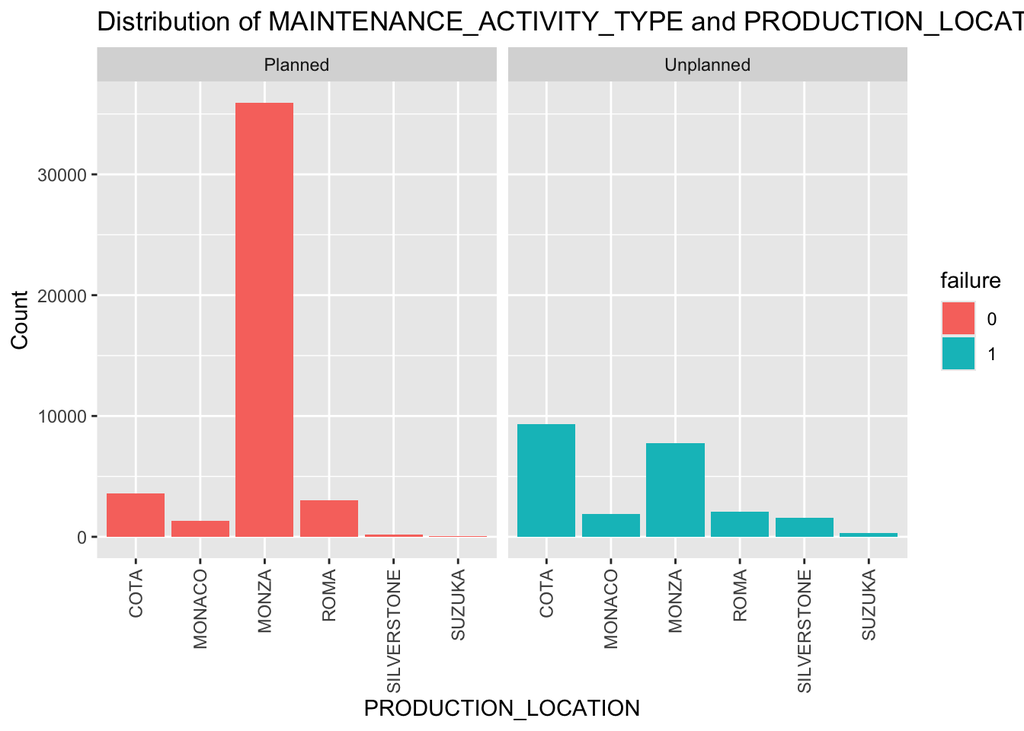

```r
# Bar Chart between MAINTENANCE_ACTIVITY_TYPE and PRODUCTION_LOCATION by failure

data_clean %>%
  ggplot(mapping = aes(x = PRODUCTION_LOCATION, fill = failure)) +
  geom_bar(position = "dodge") +
  facet_wrap(~ MAINTENANCE_ACTIVITY_TYPE) +
  theme(axis.text.x = element_text(angle = 90, vjust = 0.5, hjust=1),
        axis.text.y = element_text(angle = 0)) +
  labs(title = "Distribution of MAINTENANCE_ACTIVITY_TYPE and PRODUCTION_LOCATION by failure",
       x = "PRODUCTION_LOCATION",
       y = "Count",
       fill = "failure")
```

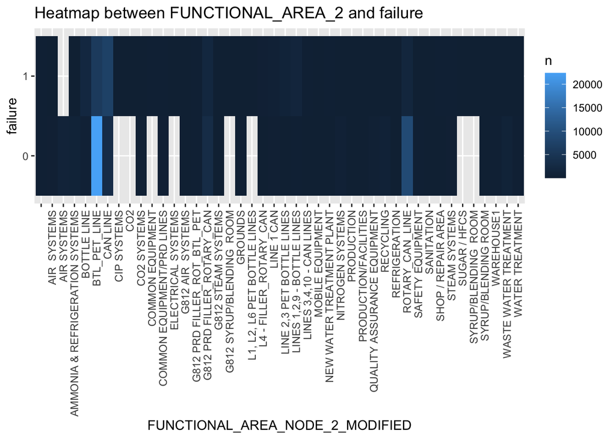

```r
# Heatmap between FUNCTIONAL_AREA_2 and failure

data_clean %>%
  count(FUNCTIONAL_AREA_NODE_2_MODIFIED, failure) %>%
  ggplot(mapping = aes(x = FUNCTIONAL_AREA_NODE_2_MODIFIED, y = failure)) +
  geom_tile(mapping = aes(fill = n)) +
  theme(axis.text.x = element_text(angle = 90, vjust = 0.5, hjust=1),
        axis.text.y = element_text(angle = 0)) +
  labs(title = "Heatmap between FUNCTIONAL_AREA_2 and failure")
```

From the heatmap above it can be seen that the highest number of failures occurred in CAN_LINE and the highest number of planned maintenance occurred in BTL_PET_LINE.

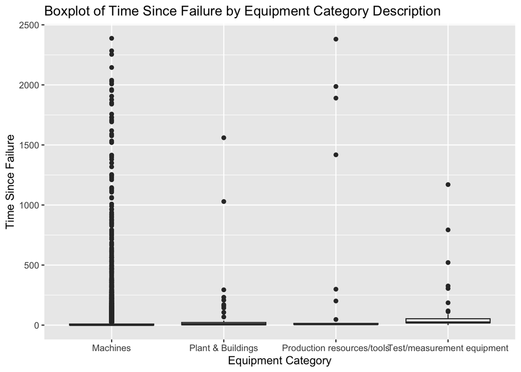

```r
# Boxplot of time_since_failure across Maintenance Activity Types
ggplot(data_clean, aes(x = EQUIP_CAT_DESC, y = time_since_failure)) +
  geom_boxplot() +
  labs(title = "Boxplot of Time Since Failure by Equipment Category Description", x = "Equipment Category", y = "Time Since Failure")
```

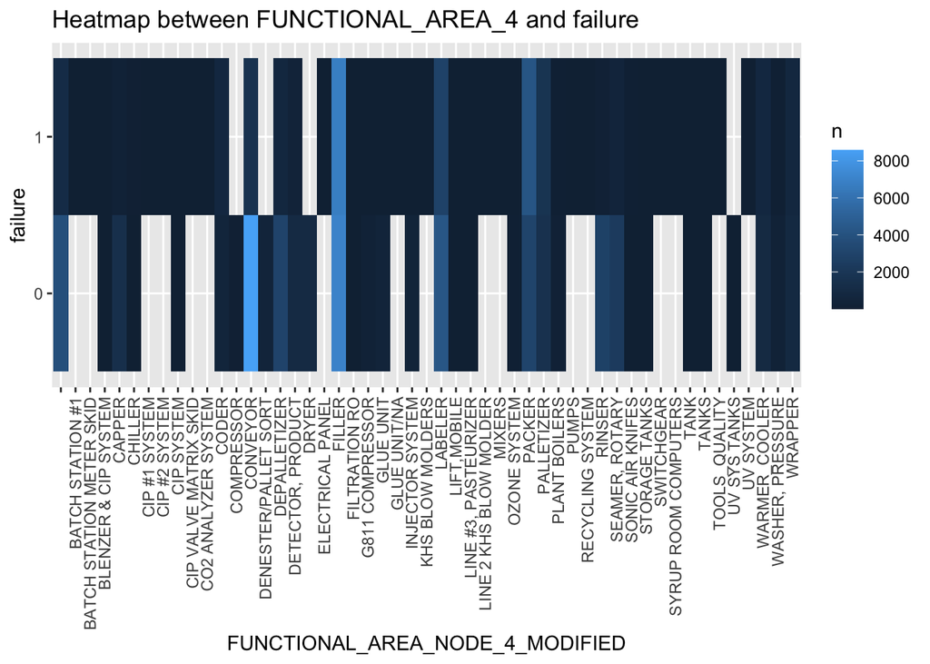

```r
# Heatmap between FUNCTIONAL_AREA_4 and failure

data_clean %>%
  count(FUNCTIONAL_AREA_NODE_4_MODIFIED, failure) %>%
  ggplot(mapping = aes(x = FUNCTIONAL_AREA_NODE_4_MODIFIED, y = failure)) +
  geom_tile(mapping = aes(fill = n)) +
  theme(axis.text.x = element_text(angle = 90, vjust = 0.5, hjust=1),
        axis.text.y = element_text(angle = 0)) +
  labs(title = "Heatmap between FUNCTIONAL_AREA_4 and failure")
```

# Results, Findings and Conclusion

The exploratory data analysis (EDA) on Swire’s dataset, containing over 1.4 million observations, revealed significant missing values in some key columns like “MAINTENANCE_ITEM” (90% missing) and “EQUIPMENT_ID” (80% missing). To proceed with the analysis, missing equipment IDs were imputed based on preceding values, assuming that a single Equipment ID may represent multiple components.

Nearly 90% of the maintenance was unplanned, suggesting heavy reliance on reactive maintenance. After doing data cleaning some patterns emerged showing that newly installed equipment tends to perform well without failures, and equipment with planned maintenance towards the end of its lifecycle also experienced fewer failures. Plants with more scheduled maintenance, like MONZA, had lower failure rates, while COTA, with less planned maintenance, had higher failure rates.

### Group Member Contribution

Notebook writing and structuring: Ahsan Ahmad, Rylan Tribush, Charlie Vandel, Scott Silverstein Data Cleanup: Ahsan Ahmad, Rylan Tribush, Charlie Vandel, Scott Silverstein Data Visualizations: Ahsan Ahmad, Rylan Tribush, Charlie Vandel, Scott Silverstein Compilation: Charlie Vandel

Most of the time on this project was a collaborative effort. We did not assign individual tasks to each person and the final output was gathered with a collective effort.